# Price Sensitivity, Seasonality, and Sales Performance Across Rainoil Retail Outlets: An Exploratory and Inferential Analysis of 2024–2025 Fuel Sales Data

## 7.3 Hypothesis 3 — Does season or festive period significantly affect PMS volume? (One-Way ANOVA)

**H₀:** Mean monthly PMS volume is the same across all demand periods (Dry Season, Early Rainy, Peak Rainy, Late Rainy, Easter, Christmas).

**H₁:** At least one demand period has a significantly different mean PMS volume — i.e. seasonality and festive periods matter beyond price alone.

```r
season_data <- stations_long |>
  filter(pms_vol > 0, !is.na(demand_period))

# One-way ANOVA on log volume across demand periods
season_anova <- aov(log1p(pms_vol) ~ demand_period, data = season_data)
cat("=== ANOVA: PMS Volume ~ Demand Period ===\n")
```

```
=== ANOVA: PMS Volume ~ Demand Period ===
```

```r
print(summary(season_anova))
```

```
                Df Sum Sq Mean Sq F value   Pr(>F)
demand_period    5   14.4  2.8845   7.612 3.94e-07 ***
Residuals     4290 1625.6  0.3789
---
Signif. codes:  0 '***' 0.001 '**' 0.01 '*' 0.05 '.' 0.1 ' ' 1
```

```r
# Eta-squared effect size
ss_tab <- summary(season_anova)[[1]]
eta_sq  <- ss_tab["demand_period", "Sum Sq"] / sum(ss_tab[, "Sum Sq"])
cat("\nEta-squared (effect size):", round(eta_sq, 4), "\n")
```

```
Eta-squared (effect size): 0.0088
```

```r
cat("Interpretation:", case_when(
  eta_sq < 0.01 ~ "Negligible",
  eta_sq < 0.06 ~ "Small",
  eta_sq < 0.14 ~ "Medium",
  TRUE          ~ "Large"
))
```

```
Interpretation: Negligible
```

```r
# Tukey HSD post-hoc
tukey_season <- TukeyHSD(season_anova, "demand_period")
tukey_df <- as.data.frame(tukey_season$demand_period) |>
  rownames_to_column("Comparison") |>
  rename(Difference = diff, Lower = lwr, Upper = upr,
         `p (adjusted)` = `p adj`) |>
  mutate(Significant = if_else(`p (adjusted)` < 0.05, "Yes ✓", "No"),
         across(where(is.numeric), ~ round(.x, 4))) |>
  arrange(`p (adjusted)`)

tukey_df |>
  kable(caption = "Tukey HSD: Demand Period Pairwise Comparisons") |>
  kable_styling(bootstrap_options = c("striped","hover","condensed"),
                full_width = TRUE) |>
  row_spec(which(tukey_df$Significant == "Yes ✓"), background = "#d4edda")
```

Tukey HSD: Demand Period Pairwise Comparisons

| Comparison | Difference | Lower | Upper | p (adjusted) | Significant |
| --- | --- | --- | --- | --- | --- |
| Peak Rainy (Jun-Sep)-Dry Season (Jan-Mar) | -0.1183 | -0.1895 | -0.0470 | 0.0000 | Yes ✓ |
| Peak Rainy (Jun-Sep)-Apr (Easter) | -0.1580 | -0.2620 | -0.0540 | 0.0002 | Yes ✓ |
| Late Rainy (Oct-Nov)-Apr (Easter) | -0.1432 | -0.2568 | -0.0296 | 0.0044 | Yes ✓ |
| Late Rainy (Oct-Nov)-Dry Season (Jan-Mar) | -0.1034 | -0.1881 | -0.0188 | 0.0066 | Yes ✓ |
| Dec (Christmas)-Apr (Easter) | -0.1320 | -0.2624 | -0.0017 | 0.0451 | Yes ✓ |
| Peak Rainy (Jun-Sep)-Early Rainy (May) | -0.0967 | -0.2006 | 0.0072 | 0.0850 | No |
| Dry Season (Jan-Mar)-Dec (Christmas) | 0.0923 | -0.0139 | 0.1984 | 0.1306 | No |
| Late Rainy (Oct-Nov)-Early Rainy (May) | -0.0819 | -0.1954 | 0.0316 | 0.3106 | No |
| Early Rainy (May)-Dec (Christmas) | 0.0707 | -0.0596 | 0.2010 | 0.6336 | No |
| Early Rainy (May)-Apr (Easter) | -0.0613 | -0.1930 | 0.0703 | 0.7692 | No |
| Dry Season (Jan-Mar)-Apr (Easter) | -0.0398 | -0.1475 | 0.0680 | 0.9001 | No |
| Peak Rainy (Jun-Sep)-Dec (Christmas) | -0.0260 | -0.1283 | 0.0763 | 0.9790 | No |
| Early Rainy (May)-Dry Season (Jan-Mar) | -0.0216 | -0.1292 | 0.0861 | 0.9929 | No |
| Peak Rainy (Jun-Sep)-Late Rainy (Oct-Nov) | -0.0148 | -0.0946 | 0.0650 | 0.9950 | No |
| Late Rainy (Oct-Nov)-Dec (Christmas) | -0.0112 | -0.1232 | 0.1009 | 0.9998 | No |

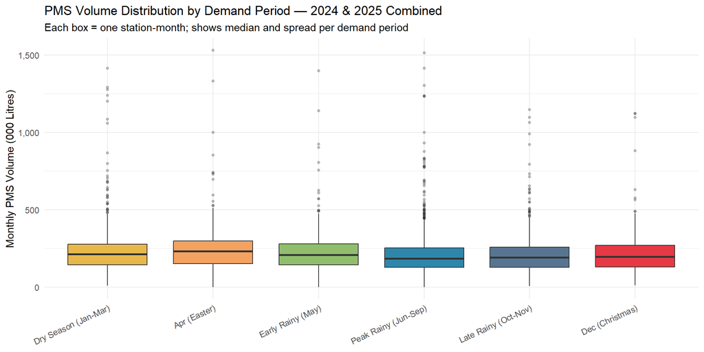

```r
# Boxplot of PMS volume by demand period
stations_long |>
  filter(pms_vol > 0) |>
  mutate(demand_period = factor(demand_period,
    levels = c("Dry Season (Jan-Mar)", "Apr (Easter)", "Early Rainy (May)",
               "Peak Rainy (Jun-Sep)", "Late Rainy (Oct-Nov)",
               "Dec (Christmas)"))) |>
  ggplot(aes(x = demand_period, y = pms_vol / 1000, fill = demand_period)) +
  geom_boxplot(outlier.alpha = 0.3, outlier.size = 1) +
  scale_fill_manual(values = c(
    "Dry Season (Jan-Mar)"   = "#E8B84B",
    "Apr (Easter)"           = "#F4A261",
    "Early Rainy (May)"      = "#90BE6D",
    "Peak Rainy (Jun-Sep)"   = "#2E86AB",
    "Late Rainy (Oct-Nov)"   = "#577590",
    "Dec (Christmas)"        = "#E63946")) +
  scale_y_continuous(labels = label_comma()) +
  labs(title = "PMS Volume Distribution by Demand Period — 2024 & 2025 Combined",
       subtitle = "Each box = one station-month; shows median and spread per demand period",
       x = NULL, y = "Monthly PMS Volume (000 Litres)") +
  theme_minimal(base_size = 11) +
  theme(legend.position  = "none",
        axis.text.x      = element_text(angle = 25, hjust = 1))
```

> **Result & Interpretation:** If the ANOVA is significant (p < 0.05), we reject H₀ — not all demand periods produce the same average PMS volume. The Tukey post-hoc table shows which specific period pairs are significantly different. **Business implication:** If December (Christmas) is significantly higher than Peak Rainy (Jun–Sep), the Retail Sales team should pre-position additional stock at high-volume stations from late November to avoid stockouts during the festive surge. If rainy season months are significantly lower, the retail supply chain team should adjust loading plans and credit terms during those months to protect cash flow. This finding, combined with the price results from Technique 5, separates what the Retail Sales team *can control* (price) from what they must *plan around* (seasons).

# 8 Technique 4 — Correlation Analysis

**Theory recap:** Correlation measures the strength and direction of linear association between two continuous variables (Adi, 2026, Ch. 8). Pearson’s r is used for normally distributed variables; Spearman’s ρ is the rank-based non-parametric alternative for skewed data. Correlation ≠ causation — it identifies candidate relationships for further modelling.

**Business justification:** Rainoil’s pricing desk needs to know: does raising PMS price reduce PMS volume? Does AGO price track PMS price? Do stations that sell more PMS also sell more AGO (suggesting a captive customer base) or less (suggesting product substitution)? These questions are answered through correlation analysis.

## 8.1 Correlation Matrix

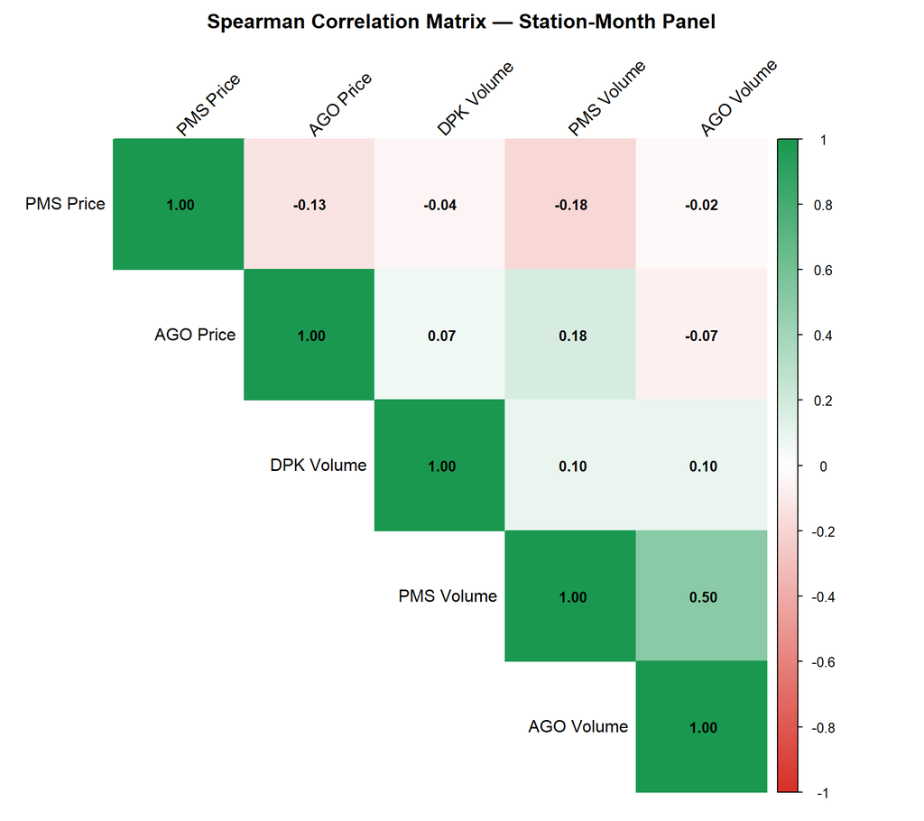

```r
# Select numeric variables for correlation
corr_data <- stations_long |>
  filter(!is.na(pms_vol), !is.na(ago_vol), !is.na(pms_price), !is.na(ago_price)) |>
  select(pms_vol, ago_vol, dpk_vol, pms_price, ago_price) |>
  drop_na()

# Spearman correlation (appropriate for skewed data)
corr_matrix <- cor(corr_data, method = "spearman", use = "complete.obs")

# Rename for display
rownames(corr_matrix) <- colnames(corr_matrix) <-
  c("PMS Volume", "AGO Volume", "DPK Volume", "PMS Price", "AGO Price")

corrplot(corr_matrix,
         method = "color",
         type = "upper",
         order = "hclust",
         addCoef.col = "black",
         number.cex = 0.85,
         tl.col = "black",
         tl.srt = 45,
         col = colorRampPalette(c("#d73027","#ffffff","#1a9850"))(200),
         title = "Spearman Correlation Matrix — Station-Month Panel",
         mar = c(0, 0, 2, 0))
```